# [The Left or Right: Who Does Best for Development?](https://nmcanenydroz.github.io/farber-mcaneny/)

## Rhon Farber and Chente McAneny-Droz

1. Introduction
2. Human-Development Index
3. Database of Political Institutions
4. Merged Analysis
5. Predictive Model
6. Conclusions

## 1. Introduction

**Authors**  
This analysis is a collaborative work produced by Tulane University students, Rhon Farber and Chente McAneny-Droz, for CMPS-3160: Introduction to Data Science, taught by Dr. Culotta in the Fall 2023 term. In addition to computer science, Rhon is double mmajoring in finance and Chente is double majoring in economics; both students belong to the class of 2025.  
**Background**  
Politics, globally, has become increasingly divisive in recent years with parties taking up more radical stances and populations being polarized to either the left or right, with little remianing in the center. This has transformed the political landscape with increasing stalemates and complete overhauls when the opposing party gains power. This begs the question how does this partisanship effect the healthy development of countries and who does it best: the left or right?

The United States has acted as a hegemon since the World Wars and has been the largest economy since before then. Despite over a hundred years sitting at the top, the United States has failed to claim the top spot, for decades now, on the Human Development Index (HDI) and has fallen out of the top 20 most developed countries as of 2021, challenging the United State's superiority complex.

Our goal is to discover which side of the political spectrum is best when it comes to development as outlined in the HDI provided by the United Nations Development Programme. In order to do this, we will use historical data on politicial institutions provided by The World Bank. This project will be a comparative analysis, and we hope to synthesize what will allow the U.S. to increase ranks in terms of the HDI based on polticial lean.

With that said, the scope of the analysis will be limited to the original G7 countries: Canada, France, Germany, Italy, Japan, the United Kingdom, and the United States. When comparing internaitonal markets and policies, countries must have alike economies due to the relativity of convergence points; the G7 counties are still among the top 10 global economies, as of now.  
**Collaboration Plan**  
Our collaboration plan is to meet at Howard-Tilton Memorial Library weekly. This weekly recurring meeting will be on Wednesdays at 3:30 PM. During this time, we will designates tasks to complete for the next meeting and go over what we had completed from the last meeting. This time will be used to go over any questions or factors we need to consider in our findings. Outside our designated meet time, both partners are expected to be reasonably responsive over text message for any questions that arise between meetings. A collaborative GitHub repository has already been set up to share resources. All Colab and Google Doc files will be easily accessible by the other partner. A master Google Sheet with personal deadlines and project deadlines will be made to make sure the project stays on schedule.  
**Data Linkage**  
Before we start, we must clone the repository we will be pulling pre-uploaded data from. This allows us to access and modify files from said external repositroy stored on Github under a collaborative account between partners. Additionally, specific libraries must be imported to run certain functions within the program; this will be done here as well.

Here is the link to our Github Repository: farber-mcaneny

```python
%cd /content
!git clone https://github.com/nmcanenydroz/farber-mcaneny

#import libraries
import pandas as pd
import numpy as np
import matplotlib.pyplot as plt
```

```
/content
Cloning into 'farber-mcaneny'...
remote: Enumerating objects: 43, done.
remote: Counting objects: 100% (43/43), done.
remote: Compressing objects: 100% (38/38), done.
remote: Total 43 (delta 9), reused 0 (delta 0), pack-reused 0
Receiving objects: 100% (43/43), 4.01 MiB | 7.31 MiB/s, done.
Resolving deltas: 100% (9/9), done.
```

## 2. Human-Development Index

**Background**  
The Human-Development Index (HDI) is a metric developed by the United Nations and launched in 1990. The summary measure is a "geometric mean of normalized indices" across three main dimensions: health, education, and stardard of living. Through the many indicators taken into account across the different dimensions, countries are assigned a score between 0 and 1 then ranked accordingly. Though economic facotrs are taken into account, this metric was designed to access global development and quality of life.

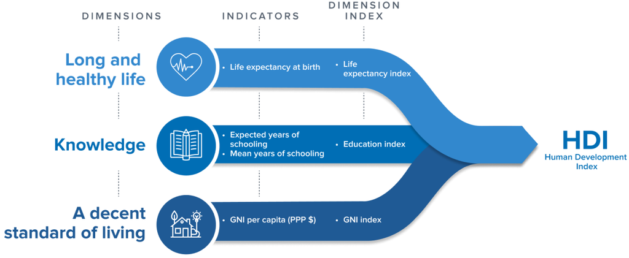

Figure 1: [United Nations Development Programme Chart](https://hdr.undp.org/data-center/human-development-index#/indicies/HDI)

**Data Sets**  
We took two data sets off of the United Nations Development Programme (UNDP) website's data center  
Both files can be found on this page: [UNDP Data Center](https://hdr.undp.org/data-center/documentation-and-downloads)

1. [All composite indices and components time series (1990-2021)](https://hdr.undp.org/sites/default/files/2021-22_HDR/HDR21-22_Composite_indices_complete_time_series.csv)
- Contains data on 206 individual countries, regions, and development classes from 1990-2021
- Indexed by country and each column indicates the HDI measue and accompanying year totalling to 1,000 columns
- Contains the latest HDI rank in 2021
- This dataset will be pivotal in predictive modeling determining changes in HDI score and rank
1. [Metadata](https://hdr.undp.org/sites/default/files/2021-22_HDR/HDR21-22_Composite_indices_metadata.xlsx)
- Contains variable definitons for the previous dataset
- Will be used as a reference for variables

**Extraction, Transform, and Load**  
Taking the raw link from the Github repository, we preform a simple Pandas read function and assign it to a variable. Since the metadata will only be used for reference, we will load the two datasets in the same step.

```python
#load data
HDI = pd.read_csv("https://raw.githubusercontent.com/nmcanenydroz/farber-mcaneny/data/HDI_Rankings.csv") #composite indicies
HDI_def = pd.read_excel("https://github.com/nmcanenydroz/farber-mcaneny/raw/data/HDI_Definitions.xlsx") #metadata
HDI.head() #output
```

|  | iso3 | country | hdicode | region | hdi_rank_2021 | hdi_1990 | hdi_1991 | hdi_1992 | hdi_1993 | hdi_1994 | ... | mf_2012 | mf_2013 | mf_2014 | mf_2015 | mf_2016 | mf_2017 | mf_2018 | mf_2019 | mf_2020 | mf_2021 |
| --- | --- | --- | --- | --- | --- | --- | --- | --- | --- | --- | --- | --- | --- | --- | --- | --- | --- | --- | --- | --- | --- |
| 0 | AFG | Afghanistan | Low | SA | 180.0 | 0.273 | 0.279 | 0.287 | 0.297 | 0.292 | ... | 1.86 | 1.88 | 1.66 | 1.62 | 1.66 | 1.41 | 1.32 | 1.38 | 1.38 | 1.38 |
| 1 | AGO | Angola | Medium | SSA | 148.0 | NaN | NaN | NaN | NaN | NaN | ... | 4.09 | 4.53 | 3.97 | 3.59 | 2.79 | 2.64 | 2.28 | 2.18 | 2.18 | 2.18 |
| 2 | ALB | Albania | High | ECA | 67.0 | 0.647 | 0.629 | 0.614 | 0.617 | 0.624 | ... | 12.44 | 11.49 | 13.14 | 12.61 | 14.39 | 14.46 | 12.85 | 12.96 | 12.96 | 12.96 |
| 3 | AND | Andorra | Very High | NaN | 40.0 | NaN | NaN | NaN | NaN | NaN | ... | NaN | NaN | NaN | NaN | NaN | NaN | NaN | NaN | NaN | NaN |
| 4 | ARE | United Arab Emirates | Very High | AS | 26.0 | 0.728 | 0.739 | 0.742 | 0.748 | 0.755 | ... | 49.56 | 49.68 | 55.49 | 59.76 | 64.95 | 75.61 | 65.97 | 68.95 | 68.95 | 68.95 |

5 rows × 1008 columns

Next, we are going to begin data cleaning. Since we are only focusing on the original G7 countires, we can drop all other data. Let's keep the world average as well, just as a benchmark.

```python
HDI['country'].unique() #checking syntax/abbreviations of the countries

G7 = ["Canada", "France", "Germany", "Italy", "Japan", "United Kingdom", "United States", "World"] #store countries to keep in variable
HDI = HDI[HDI['country'].isin(G7)] #keep only G7 countries

# drop non-time series variables
HDI = HDI.drop('iso3', axis=1)
HDI = HDI.drop('region', axis=1)
HDI = HDI.drop('hdicode', axis=1)
HDI = HDI.drop('rankdiff_hdi_phdi_2021', axis=1)
HDI = HDI.drop('gdi_group_2021', axis=1)

HDI.info() #check data types

HDI.head(10) #updated df
```

```
<class 'pandas.core.frame.DataFrame'>
Int64Index: 8 entries, 29 to 205
Columns: 1003 entries, country to mf_2021
dtypes: float64(1002), object(1)
memory usage: 62.8+ KB
```

|  | country | hdi_rank_2021 | hdi_1990 | hdi_1991 | hdi_1992 | hdi_1993 | hdi_1994 | hdi_1995 | hdi_1996 | hdi_1997 | ... | mf_2012 | mf_2013 | mf_2014 | mf_2015 | mf_2016 | mf_2017 | mf_2018 | mf_2019 | mf_2020 | mf_2021 |
| --- | --- | --- | --- | --- | --- | --- | --- | --- | --- | --- | --- | --- | --- | --- | --- | --- | --- | --- | --- | --- | --- |
| 29 | Canada | 15.0 | 0.860 | 0.864 | 0.868 | 0.866 | 0.872 | 0.876 | 0.879 | 0.880 | ... | 34.830000 | 35.000000 | 33.820000 | 34.420000 | 35.460000 | 36.480000 | 35.840000 | 35.050000 | 35.050000 | 35.05000 |
| 44 | Germany | 9.0 | 0.829 | 0.835 | 0.842 | 0.852 | 0.858 | 0.863 | 0.868 | 0.874 | ... | 20.360000 | 20.360000 | 20.700000 | 20.060000 | 20.500000 | 21.290000 | 20.230000 | 19.400000 | 19.400000 | 19.40000 |
| 58 | France | 28.0 | 0.791 | 0.799 | 0.806 | 0.809 | 0.823 | 0.828 | 0.833 | 0.838 | ... | 20.900000 | 20.950000 | 20.750000 | 20.150000 | 19.790000 | 19.700000 | 17.610000 | 17.100000 | 17.100000 | 17.10000 |
| 61 | United Kingdom | 18.0 | 0.804 | 0.809 | 0.816 | 0.820 | 0.828 | 0.828 | 0.834 | 0.842 | ... | 17.940000 | 17.860000 | 19.090000 | 18.970000 | 18.270000 | 18.200000 | 18.010000 | 17.850000 | 17.850000 | 17.85000 |
| 84 | Italy | 30.0 | 0.778 | 0.783 | 0.789 | 0.795 | 0.804 | 0.810 | 0.816 | 0.824 | ... | 14.320000 | 13.740000 | 13.370000 | 13.160000 | 13.480000 | 13.550000 | 12.330000 | 11.850000 | 11.850000 | 11.85000 |
| 87 | Japan | 19.0 | 0.845 | 0.849 | 0.850 | 0.855 | 0.861 | 0.863 | 0.868 | 0.871 | ... | 22.570000 | 22.800000 | 22.420000 | 20.300000 | 19.280000 | 19.470000 | 18.890000 | 18.180000 | 18.180000 | 18.18000 |
| 184 | United States | 21.0 | 0.872 | 0.873 | 0.878 | 0.880 | 0.884 | 0.885 | 0.887 | 0.890 | ... | 28.520000 | 28.090000 | 28.230000 | 28.330000 | 28.060000 | 28.120000 | 29.140000 | 29.650000 | 29.650000 | 29.65000 |
| 205 | World | NaN | 0.601 | 0.604 | 0.607 | 0.610 | 0.614 | 0.619 | 0.624 | 0.629 | ... | 12.186601 | 12.474065 | 12.520563 | 12.372667 | 12.277707 | 12.277878 | 12.220286 | 12.375236 | 12.325166 | 12.27192 |

8 rows × 1003 columns

We need to transform this dataset and set an index because the data is being sorted by row number and is in wide format. To do this, we need to iterate through the variable names and extract the year to create a separate year column.

```python
# Separate non-time-scaled variables if needed
non_time_scaled = HDI[['country', 'hdi_rank_2021', 'gii_rank_2021']]
HDI = HDI.drop(columns=['hdi_rank_2021', 'gii_rank_2021'])

# Melt the DataFrame
HDI_melted = HDI.melt(id_vars=['country'], var_name='year_measure', value_name='value')

# Split 'year_measure' into two columns 'year' and 'measure'
HDI_melted[['measure', 'year']] = HDI_melted['year_measure'].str.extract(r'([a-zA-Z_]+)(\d+)')
HDI_melted.drop(columns='year_measure', inplace=True)

# Convert year to numeric
HDI_melted['year'] = pd.to_numeric(HDI_melted['year'], errors='coerce')

# Drop rows with NaN in 'year' if any
HDI_melted = HDI_melted.dropna(subset=['year'])

# Pivot the table
HDI_pivoted = HDI_melted.pivot_table(index=['country', 'year'], columns='measure', values='value', aggfunc='first')

# Reset index to have country and year as columns
HDI_final = HDI_pivoted.reset_index()

# Fix column names if necessary
HDI_final.columns.name = None

# Remove any trailing underscores
HDI_final.columns = HDI_final.columns.str.rstrip('_')

# Select all rows except the first one
HDI_final = HDI_final.iloc[1:]

# drop inconsistent time-series variables (starts in 2010, not necessary)
HDI_final = HDI_final.drop('coef_ineq', axis=1)
HDI_final = HDI_final.drop('loss', axis=1)
HDI_final = HDI_final.drop('ineq_le', axis=1)
HDI_final = HDI_final.drop('ineq_edu', axis=1)
HDI_final = HDI_final.drop('ineq_inc', axis=1)
HDI_final = HDI_final.drop('co', axis=1)

# Display the first few rows of the transformed DataFrame
HDI_final.head(10)

# Make a separate dataframe that excludes the world averages
HDI_G7 = HDI_final[HDI_final['country'] != 'World']
```

**Exploratory Data Analysis**  
Now that everything is loaded and transformed, let's explore trends within and create graphics to learn more about the UNDP dataset.

A) Let's start with simple summary statistics in order to understand the spread of the data. We should exclude the world average since it's a benchmark, and it will weigh down the statistics.

```python
stat = HDI_G7['hdi'].describe() #use filtered df without world average
print(stat) #output
```

```
count    224.000000
mean       0.884933
std        0.036440
min        0.778000
25%        0.866000
50%        0.889000
75%        0.913250
max        0.948000
Name: hdi, dtype: float64
```

As we can see, the standard deviation is quite low meaning much of the data is centered around the mean of 0.884933. For the G7 countries the mean is very high according to the threshold, as listed on the UNDP website, of ≥ 0.8, even the minimum is high and only slightly falls out of the very high categorization. Globally, all of the G7 countries are leaders in HCI scores and have consistently been.

B) Next let's make a correlation matrix that compares all of the variable to the single HDI variable in an effort to understand the types of relationship each one has. All the variables are used to compute the final HDI score so there is an established relationship, but let's see the magnitude.

```python
HDI_corr = HDI_G7.corr()['hdi'] #create correlation matrix only by the hdi variable
HDI_corr.abs().sort_values(ascending=False) #sort from strongest to weakest correlations
```

```
hdi              1.000000
hdi_m            0.987939
hdi_f            0.984156
se_m             0.930239
se_f             0.895607
mys_f            0.894586
mys              0.894299
ihdi             0.883862
mys_m            0.877203
year             0.802706
gni_pc_f         0.738864
gnipc            0.692018
eys              0.650410
eys_m            0.636044
le_m             0.626480
pr_m             0.625355
pr_f             0.625355
eys_f            0.618409
lfpr_f           0.573178
gni_pc_m         0.554645
le               0.529518
gii              0.480361
le_f             0.401160
gdi              0.331170
phdi             0.302999
diff_hdi_phdi    0.226837
mf               0.222624
lfpr_m           0.082819
abr              0.055515
mmr              0.043379
Name: hdi, dtype: float64
```

The strongest relationships involve secondary education, mean years in school, and gross national income per capita. Noticeably there are two variables that deal directly with government: pr_f and pr_m. These are the share of seats in parliament or legislative branch held by females (pr_f) and males (pr_f). Their coefficeints are indentical and have a strong relationship with HDI. Historically, there has been a relationship between gender and development due to inequality in quality of life which explains the strength of the coefficents.

C) Finally, let's chart the HDI scores over time and compare the both G7 countries and the world average

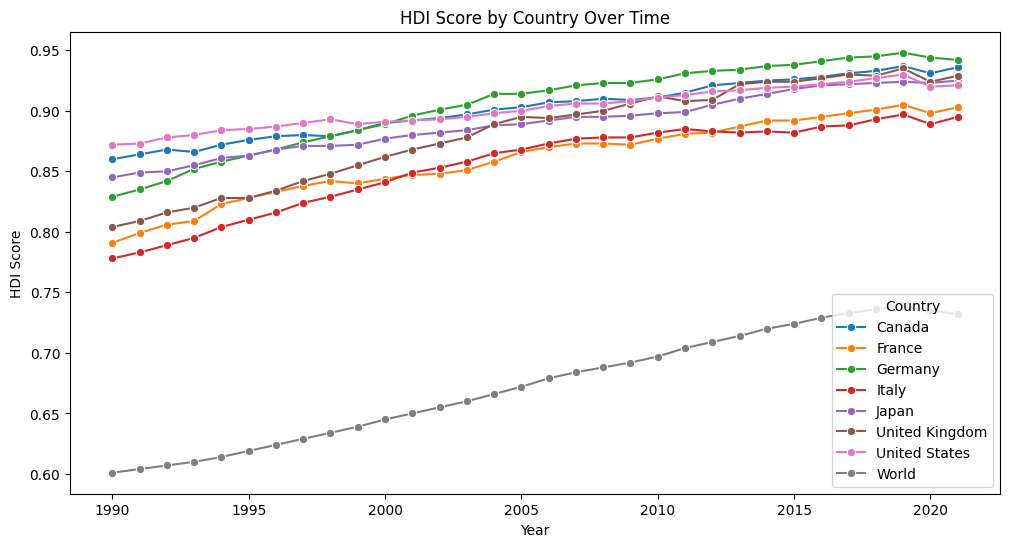

```python
import matplotlib.pyplot as plt
import seaborn as sns

plt.figure(figsize=(12, 6))

# plot x-axis as year and y-axis as hdi with each country
sns.lineplot(data=HDI_final, x='year', y='hdi', hue='country', marker='o')

# plot descriptions
plt.title('HDI Score by Country Over Time')
plt.ylabel('HDI Score')
plt.xlabel('Year')
plt.legend(title='Country', loc='lower right')
plt.show()
```

## 3. Database of Political Institutions

**Background**  
Founded in 1947, The World Bank (WB) is an international financial institution that funds development projects in low and middle-income countries with the goal of getting rid of poverty. Through this mission, they keep extensive political, social, and economic datasets. The following dataset tracks electoral and institutional data over the years and gives information about the political spectrum, number of seats, number of opposing parties, and specific metrics such as polarization, fragmentation, and political cohesion. The most pertinent data will be on the entries on the political spectrum: left, center, and right.

**Data Sets**  
We took two datasets off The World Bank Data Catalog.  
Both can be found on this page: [WB Data Catalog](https://datacatalog.worldbank.org/search/dataset/0039819/Database-of-Political-Institutions)

1. [Database of Political Institutions](https://datacatalogfiles.worldbank.org/ddh-published/0039819/DR0049516/dpi2012.xls?versionId=2023-01-19T04:35:33.9334248Z)
- Contains data on 177 individual countries each having 113 variables from 1975-2012.
- This dataset is important to understand what kind of political power and structure was in play for each year determine HDI score and rank.
- We can use this data to compare the HDI score to the political spectrum
1. [Metadata](https://documents1.worldbank.org/curated/en/870551468766532480/text/multi-page.txt)
- Contains variable definitons for all 113 variables in the dataset.
- Will be used as a reference for variables.

**Extraction, Transform, and Load**  
Taking the raw link from the Github repository, we preform a simple Pandas read function and assign it to a variable. The metadata will only be used for reference.

```python
politics = pd.read_excel("https://github.com/nmcanenydroz/farber-mcaneny/raw/data/dpi2012.xls") #load from raw
politics #output
```

|  | countryname | ifs | year | system | yrsoffc | finittrm | yrcurnt | multpl | military | defmin | ... | checks | stabs_strict | stabs | stabns_strict | stabns | tenlong_strict | tenlong | tenshort_strict | tenshort | polariz |
| --- | --- | --- | --- | --- | --- | --- | --- | --- | --- | --- | --- | --- | --- | --- | --- | --- | --- | --- | --- | --- | --- |
| 0 | South Sudan | NaN | 2011 | Presidential | 1.0 | NaN | NaN | 1.0 | 1.0 | 1.0 | ... | 1.0 | NaN | NaN | NaN | NaN | 1.0 | 1.0 | 1.0 | 1.0 | 0.0 |
| 1 | South Sudan | NaN | 2012 | Presidential | 2.0 | NaN | NaN | 1.0 | 1.0 | 1.0 | ... | 1.0 | 0.00 | 0.00 | 0.000000 | 0.000000 | 2.0 | 2.0 | 2.0 | 2.0 | 0.0 |
| 2 | Turk Cyprus | 0 | 1975 | -999 | 1.0 | -999.0 | -999.0 | -999.0 | NaN | NaN | ... | NaN | NaN | NaN | NaN | NaN | NaN | NaN | NaN | NaN | NaN |
| 3 | Turk Cyprus | 0 | 1976 | Presidential | 1.0 | 1.0 | 0.0 | 1.0 | NaN | NaN | ... | 1.0 | NaN | NaN | NaN | NaN | 1.0 | 1.0 | 1.0 | 1.0 | 0.0 |
| 4 | Turk Cyprus | 0 | 1977 | Presidential | 2.0 | 1.0 | 4.0 | 1.0 | NaN | NaN | ... | 3.0 | 0.00 | 0.00 | 0.000000 | 0.000000 | 2.0 | 2.0 | 1.0 | 1.0 | 0.0 |
| ... | ... | ... | ... | ... | ... | ... | ... | ... | ... | ... | ... | ... | ... | ... | ... | ... | ... | ... | ... | ... | ... |
| 6759 | Zimbabwe | ZWE | 2008 | Presidential | 21.0 | 1.0 | 0.0 | 1.0 | 0.0 | 0.0 | ... | 3.0 | 0.00 | 0.00 | 0.000000 | 0.000000 | 28.0 | 28.0 | 21.0 | 21.0 | 0.0 |
| 6760 | Zimbabwe | ZWE | 2009 | Presidential | 22.0 | 1.0 | 4.0 | 1.0 | 0.0 | 0.0 | ... | 4.0 | 0.25 | 0.25 | 0.333333 | 0.333333 | 22.0 | 22.0 | 1.0 | 1.0 | NaN |
| 6761 | Zimbabwe | ZWE | 2010 | Presidential | 23.0 | 1.0 | 3.0 | 1.0 | 0.0 | 0.0 | ... | 4.0 | 0.00 | 0.00 | 0.000000 | 0.000000 | 23.0 | 23.0 | 2.0 | 2.0 | NaN |
| 6762 | Zimbabwe | ZWE | 2011 | Presidential | 24.0 | 1.0 | 2.0 | 1.0 | 0.0 | 0.0 | ... | 4.0 | 0.00 | 0.00 | 0.000000 | 0.000000 | 24.0 | 24.0 | 3.0 | 3.0 | NaN |
| 6763 | Zimbabwe | ZWE | 2012 | Presidential | 25.0 | 1.0 | 1.0 | 1.0 | 0.0 | 0.0 | ... | 4.0 | 0.00 | 0.00 | 0.000000 | 0.000000 | 25.0 | 25.0 | 4.0 | 4.0 | NaN |

6764 rows × 125 columns

In order to keep only the G7 countries however, we will need to rename a few of the countries, namely, UK to United Kingdom, US to United States, and FRG/Germany to just Germany.

We will print the unique countries and the head of the table to make sure all the changes were done properly.

```python
# Define columns
columns = ['countryname', 'year', 'execme', 'execrlc', 'herfgov', 'totalseats', 'gov1me', 'gov1rlc',
           'opp1me', 'opp1rlc', 'polariz']

politics = politics[columns]

politics = politics.rename(columns={'countryname': 'country'}) #keeping country variable consistent for merge

# Define the replacements
replacements = {'USA': 'United States', 'FRG/Germany': 'Germany', 'UK': 'United Kingdom'}

# Replace the values in the 'country' column
politics['country'] = politics['country'].replace(replacements)

politics = politics[politics['country'].isin(G7)] #keep only G7 countries

print(politics['country'].unique()) #prints each country
politics.head()
```

```
['Canada' 'Germany' 'France' 'United Kingdom' 'Italy' 'Japan'
 'United States']
```

|  | country | year | execme | execrlc | herfgov | totalseats | gov1me | gov1rlc | opp1me | opp1rlc | polariz |
| --- | --- | --- | --- | --- | --- | --- | --- | --- | --- | --- | --- |
| 1066 | Canada | 1975 | LPC | Left | 1.0 | 263 | LPC | Left | PCP | Right | 0.0 |
| 1067 | Canada | 1976 | LPC | Left | 1.0 | 263 | LPC | Left | PCP | Right | 0.0 |
| 1068 | Canada | 1977 | LPC | Left | 1.0 | 258 | LPC | Left | PCP | Right | 0.0 |
| 1069 | Canada | 1978 | LPC | Left | 1.0 | 258 | LPC | Left | PCP | Right | 0.0 |
| 1070 | Canada | 1979 | LPC | Left | 1.0 | 258 | LPC | Left | PCP | Right | 0.0 |

It looks like several columns have repeated categories for the data they represent. For example, we will only be looking at 7 countries so making sure 'country' is a 'category' dtype so it can be more efficient. Next we will check all of the data types, and makes changes as appropriate.

```python
politics.dtypes #check types
```

```
country        object
year            int64
execme         object
execrlc        object
herfgov       float64
totalseats      int64
gov1me         object
gov1rlc        object
opp1me         object
opp1rlc        object
polariz       float64
dtype: object
```

Looks like most of the dtypes are appropriate however we should change some of them to a 'category' rather than 'object' for efficiency. The ones that need to be changed are below:

1. country: already mentioned
2. execrlc (object): This denotes the political orientation (right, left, center) of the chief executive.
3. gov1rlc (object): Also (right, left, center)
4. opp1rlc (object): Also (right, left, center)

```python
#change type to categorical
politics['country'] = politics['country'].astype('category')
politics['execrlc'] = politics['execrlc'].astype('category')
politics['gov1rlc'] = politics['gov1rlc'].astype('category')
politics['opp1rlc'] = politics['opp1rlc'].astype('category')
```

**Exploratory Data Analysis**  
Now that everything is loaded and transformed, let's explore trends within and create graphics to learn more about the WB dataset.

A) First, let's create a countplot that shows the frequency of political lean for each of the countries to understand, historically, which way each country leans. We will use the 'exerlc' variable which the political lean of the executive (president/prime minister)

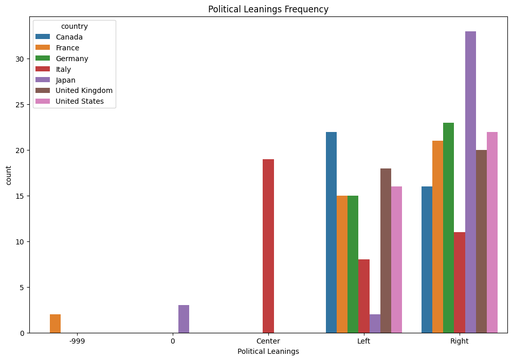

```python
plt.figure(figsize=(12, 8)) #adjust size
sns.countplot(x='execrlc', hue='country', data=politics) #use a countplot because x is categorical
plt.title('Political Leanings Frequency') #add title
plt.xlabel('Political Leanings') #provide x axis label
```

As we can see, there is a couple stray 0 entries for Japan and a couple -999 entries for France. This is because they are inbetween categories on the spectrum: right-center or left-center. Let's filter the data for Japan only and France only to research the political lean of the parties that are causing the 0 and -999. We will manually check through the data frames.

```python
japan_only = politics[politics['country'] == 'Japan'] #filter to only Japan
display(japan_only) #output
```

|  | country | year | execme | execrlc | herfgov | totalseats | gov1me | gov1rlc | opp1me | opp1rlc | polariz |
| --- | --- | --- | --- | --- | --- | --- | --- | --- | --- | --- | --- |
| 3156 | Japan | 1975 | LDP | Right | NaN | 0 | LDP | Right | Socialist | Left | NaN |
| 3157 | Japan | 1976 | LDP | Right | NaN | 0 | LDP | Right | Socialist | Left | NaN |
| 3158 | Japan | 1977 | LDP | Right | 1.000000 | 511 | LDP | Right | Socialist | Left | 2.0 |
| 3159 | Japan | 1978 | LDP | Right | 1.000000 | 520 | LDP | Right | Socialist | Left | 2.0 |
| 3160 | Japan | 1979 | LDP | Right | 1.000000 | 511 | LDP | Right | Socialist | Left | 2.0 |
| 3161 | Japan | 1980 | LDP | Right | 1.000000 | 502 | LDP | Right | Socialist | Left | 2.0 |
| 3162 | Japan | 1981 | LDP | Right | 1.000000 | 511 | LDP | Right | Socialist | Left | 0.0 |
| 3163 | Japan | 1982 | LDP | Right | 1.000000 | 456 | LDP | Right | Socialist | Left | 0.0 |
| 3164 | Japan | 1983 | LDP | Right | 1.000000 | 456 | LDP | Right | Socialist | Left | 0.0 |
| 3165 | Japan | 1984 | LDP | Right | 1.000000 | 511 | LDP | Right | Socialist | Left | 2.0 |
| 3166 | Japan | 1985 | LDP | Right | 1.000000 | 511 | LDP | Right | Socialist | Left | 2.0 |
| 3167 | Japan | 1986 | LDP | Right | 1.000000 | 511 | LDP | Right | Socialist | Left | 2.0 |
| 3168 | Japan | 1987 | LDP | Right | 0.962040 | 512 | LDP | Right | Socialist | Left | 0.0 |
| 3169 | Japan | 1988 | LDP | Right | 1.000000 | 511 | LDP | Right | Socialist | Left | 0.0 |
| 3170 | Japan | 1989 | LDP | Right | 1.000000 | 511 | LDP | Right | Socialist | Left | 0.0 |
| 3171 | Japan | 1990 | LDP | Right | 1.000000 | 511 | LDP | Right | Socialist | Left | 0.0 |
| 3172 | Japan | 1991 | LDP | Right | 1.000000 | 515 | LDP | Right | Socialist | Left | 0.0 |
| 3173 | Japan | 1992 | LDP | Right | 0.758301 | 492 | LDP | Right | SDPJ | Left | 0.0 |
| 3174 | Japan | 1993 | LDP | Right | 0.758301 | 492 | LDP | Right | SDPJ | Left | 0.0 |
| 3175 | Japan | 1994 | JNP | Right | 0.197264 | 511 | SDPJ | Left | LDP | Right | 2.0 |
| 3176 | Japan | 1995 | SDPJ | Left | 0.529525 | 509 | LDP | Right | NFP | Right | 2.0 |
| 3177 | Japan | 1996 | SDPJ | Left | 0.529525 | 509 | LDP | Right | NFP | Right | 2.0 |
| 3178 | Japan | 1997 | LDP | Right | 1.000000 | 500 | LDP | Right | NFP | Right | 0.0 |
| 3179 | Japan | 1998 | LDP | Right | 1.000000 | 500 | LDP | Right | NFP | Right | 0.0 |
| 3180 | Japan | 1999 | LDP | Right | 1.000000 | 500 | LDP | Right | NFP | Right | 0.0 |
| 3181 | Japan | 2000 | LDP | Right | 1.000000 | 500 | LDP | Right | NFP | Right | 0.0 |
| 3182 | Japan | 2001 | LDP | Right | 0.752972 | 480 | LDP | Right | DPJ | 0 | 0.0 |
| 3183 | Japan | 2002 | LDP | Right | 0.752972 | 480 | LDP | Right | DPJ | 0 | 0.0 |
| 3184 | Japan | 2003 | LDP | Right | 0.752972 | 480 | LDP | Right | DPJ | 0 | 0.0 |
| 3185 | Japan | 2004 | LDP | Right | 0.761206 | 480 | LDP | Right | DPJ | 0 | 0.0 |
| 3186 | Japan | 2005 | LDP | Right | 0.761206 | 480 | LDP | Right | DPJ | 0 | 0.0 |
| 3187 | Japan | 2006 | LDP | Right | 0.828372 | 480 | LDP | Right | DPJ | 0 | 0.0 |
| 3188 | Japan | 2007 | LDP | Right | 0.828372 | 480 | LDP | Right | DPJ | 0 | 0.0 |
| 3189 | Japan | 2008 | LDP | Right | 0.828372 | 480 | LDP | Right | DPJ | 0 | 0.0 |
| 3190 | Japan | 2009 | LDP | Right | 0.828372 | 480 | LDP | Right | DPJ | 0 | 0.0 |
| 3191 | Japan | 2010 | DPJ | 0 | 0.938669 | 480 | DPJ | 0 | LDP | Right | 0.0 |
| 3192 | Japan | 2011 | DPJ | 0 | 0.938669 | 480 | DPJ | 0 | LDP | Right | 0.0 |
| 3193 | Japan | 2012 | DPJ | 0 | 0.938669 | 480 | DPJ | 0 | LDP | Right | 0.0 |

```python
france_only = politics[politics['country'] == 'France'] #filter to only France
display(france_only) #output
```

|  | country | year | execme | execrlc | herfgov | totalseats | gov1me | gov1rlc | opp1me | opp1rlc | polariz |
| --- | --- | --- | --- | --- | --- | --- | --- | --- | --- | --- | --- |
| 2130 | France | 1975 | UDR | Right | 0.553848 | 469 | UDR | Right | PS | Left | 2.0 |
| 2131 | France | 1976 | UDR | Right | 0.553848 | 469 | UDR | Right | PS | Left | 2.0 |
| 2132 | France | 1977 | independent | -999 | 0.553848 | 469 | UDR | Right | PS | Left | NaN |
| 2133 | France | 1978 | independent | -999 | 0.553848 | 469 | UDR | Right | PS | Left | NaN |
| 2134 | France | 1979 | UDF | Right | 0.505823 | 481 | RPR | Right | PS | Left | 2.0 |
| 2135 | France | 1980 | UDF | Right | 0.505823 | 481 | RPR | Right | PS | Left | 2.0 |
| 2136 | France | 1981 | UDF | Right | 0.505823 | 481 | RPR | Right | PS | Left | 2.0 |
| 2137 | France | 1982 | PS | Left | 0.750092 | 491 | PS/MRG | Left | RPR | Right | 0.0 |
| 2138 | France | 1983 | PS | Left | 0.750092 | 491 | PS/MRG | Left | RPR | Right | 0.0 |
| 2139 | France | 1984 | PS | Left | 0.750092 | 491 | PS/MRG | Left | RPR | Right | 0.0 |
| 2140 | France | 1985 | PS | Left | 0.750092 | 491 | PS/MRG | Left | RPR | Right | 0.0 |
| 2141 | France | 1986 | PS | Left | 0.750092 | 491 | PS/MRG | Left | RPR | Right | 0.0 |
| 2142 | France | 1987 | RPR | Right | 0.371118 | 585 | RPR/UDF joint | Right | PS | Left | 2.0 |
| 2143 | France | 1988 | RPR | Right | 0.371118 | 585 | RPR/UDF joint | Right | PS | Left | 2.0 |
| 2144 | France | 1989 | PS | Left | 0.908813 | 550 | PS | Left | UDF | Right | 2.0 |
| 2145 | France | 1990 | PS | Left | 0.908813 | 550 | PS | Left | UDF | Right | 2.0 |
| 2146 | France | 1991 | PS | Left | 0.908813 | 550 | PS | Left | UDF | Right | 2.0 |
| 2147 | France | 1992 | PS | Left | 0.908813 | 550 | PS | Left | UDF | Right | 2.0 |
| 2148 | France | 1993 | PS | Left | 0.908813 | 553 | PS | Left | UDF | Right | 2.0 |
| 2149 | France | 1994 | RPR | Right | 0.502732 | 577 | RPR | Right | PS | Left | 2.0 |
| 2150 | France | 1995 | RPR | Right | 0.502732 | 577 | RPR | Right | PS | Left | 2.0 |
| 2151 | France | 1996 | RPR | Right | 0.502732 | 577 | RPR | Right | PS | Left | 2.0 |
| 2152 | France | 1997 | RPR | Right | 0.502732 | 577 | RPR | Right | PS | Left | 2.0 |
| 2153 | France | 1998 | PS | Left | 0.586364 | 577 | PS | Left | RPR | Right | 2.0 |
| 2154 | France | 1999 | PS | Left | 0.586364 | 577 | PS | Left | RPR | Right | 2.0 |
| 2155 | France | 2000 | PS | Left | 0.586364 | 577 | PS | Left | RPR | Right | 2.0 |
| 2156 | France | 2001 | PS | Left | 0.586364 | 577 | PS | Left | RPR | Right | 2.0 |
| 2157 | France | 2002 | PS | Left | 0.586364 | 577 | PS | Left | RPR | Right | 2.0 |
| 2158 | France | 2003 | UMP | Right | 0.860365 | 577 | UMP | Right | PS | Left | 0.0 |
| 2159 | France | 2004 | UMP | Right | 0.860365 | 577 | UMP | Right | PS | Left | 0.0 |
| 2160 | France | 2005 | UMP | Right | 0.860365 | 577 | UMP | Right | PS | Left | 0.0 |
| 2161 | France | 2006 | UMP | Right | 0.860365 | 577 | UMP | Right | PS | Left | 0.0 |
| 2162 | France | 2007 | UMP | Right | 0.860365 | 577 | UMP | Right | PS | Left | 0.0 |
| 2163 | France | 2008 | UMP | Right | 0.877282 | 580 | UMP | Right | PS | Left | 0.0 |
| 2164 | France | 2009 | UMP | Right | 0.877282 | 580 | UMP | Right | PS | Left | 0.0 |
| 2165 | France | 2010 | UMP | Right | 0.877282 | 580 | UMP | Right | PS | Left | 0.0 |
| 2166 | France | 2011 | UMP | Right | 0.877282 | 580 | UMP | Right | PS | Left | 0.0 |
| 2167 | France | 2012 | UMP | Right | 0.877282 | 580 | UMP | Right | PS | Left | 0.0 |

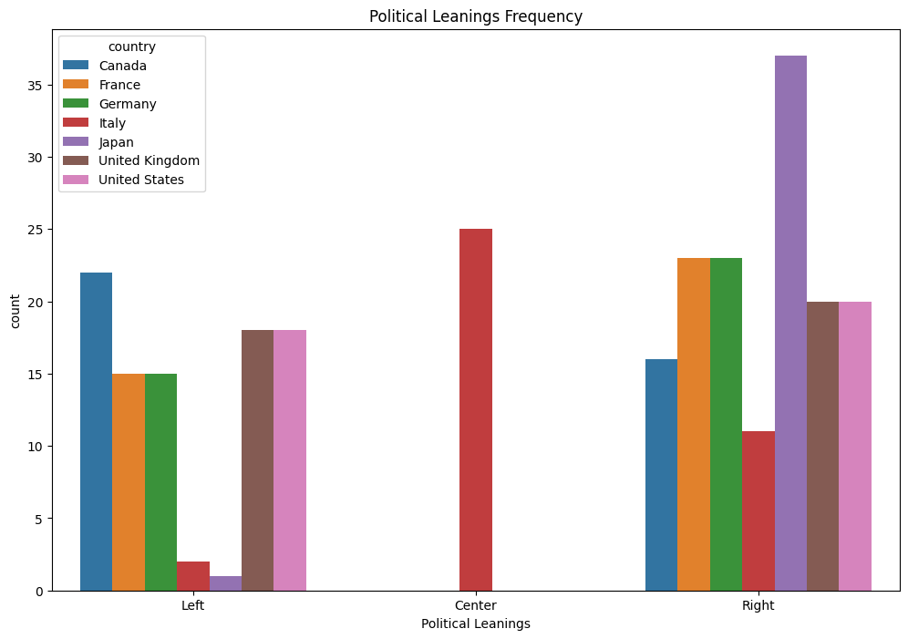

```python
#replace 0s with right by specified row number (Japan)
politics.loc[3191, 'execrlc'] = 'Right'
politics.loc[3191, 'gov1rlc'] = 'Right'
politics.loc[3192, 'execrlc'] = 'Right'
politics.loc[3192, 'gov1rlc'] = 'Right'
politics.loc[3193, 'execrlc'] = 'Right'
politics.loc[3193, 'gov1rlc'] = 'Right'

#replace -999s with right by specified row number (France)
politics.loc[2132, 'execrlc'] = 'Right'
politics.loc[2133, 'gov1rlc'] = 'Right'

#re-run above plote
plt.figure(figsize=(12, 8))
sns.countplot(x='gov1rlc', hue='country', data=politics, order=['Left', 'Center', 'Right']) #redorder the bars
plt.title('Political Leanings Frequency')
plt.xlabel('Political Leanings')
```

## 4. Merged Analysis

To begin understanding the relationship between HDI score and political lean, we need to merge the two datasets. Since the data sets were already prepared and modified to merge, all that is left is to preform an inner merge. We will merge on the two common columns: year and country

```python
#merge dataframes on 'country' and 'year'
merged_df = pd.merge(HDI_G7, politics, on=['country', 'year'], how='inner')
merged_df.head()
```

|  | country | year | abr | diff_hdi_phdi | eys | eys_f | eys_m | gdi | gii | gni_pc_f | ... | se_m | execme | execrlc | herfgov | totalseats | gov1me | gov1rlc | opp1me | opp1rlc | polariz |
| --- | --- | --- | --- | --- | --- | --- | --- | --- | --- | --- | --- | --- | --- | --- | --- | --- | --- | --- | --- | --- | --- |
| 0 | Canada | 1990 | 27.610 | 28.372093 | 16.767969 | 17.242649 | 16.312469 | 0.983 | 0.193 | 23904.28896 | ... | 82.414486 | PCP | Right | 1.0 | 295 | PCP | Right | LPC | Left | 0.0 |
| 1 | Canada | 1991 | 26.658 | 26.620370 | 17.126560 | 17.599480 | 16.673040 | 0.983 | 0.189 | 23279.82550 | ... | 83.912903 | PCP | Right | 1.0 | 295 | PCP | Right | LPC | Left | 0.0 |
| 2 | Canada | 1992 | 26.245 | 26.958525 | 17.263720 | 17.743641 | 16.803530 | 0.984 | 0.188 | 23148.48482 | ... | 85.438564 | PCP | Right | 1.0 | 295 | PCP | Right | LPC | Left | 0.0 |
| 3 | Canada | 1993 | 25.498 | 26.905312 | 16.850031 | 17.143600 | 16.568150 | 0.980 | 0.185 | 23510.21681 | ... | 86.964224 | PCP | Right | 1.0 | 295 | PCP | Right | LPC | Left | 0.0 |
| 4 | Canada | 1994 | 25.470 | 27.866972 | 16.959970 | 17.234150 | 16.695801 | 0.979 | 0.185 | 24223.88725 | ... | 88.489885 | LPC | Left | 1.0 | 295 | LPC | Left | BQ | 0 | 0.0 |

5 rows × 40 columns

A) Now with the merged data set, lets create a line graph showing the HDI (Human Development Index) score over time for each G7 country, with the color of the line indicating the political party of the chief executive (left, right, center). This could show if there's any apparent correlation between political orientation and HDI trends.

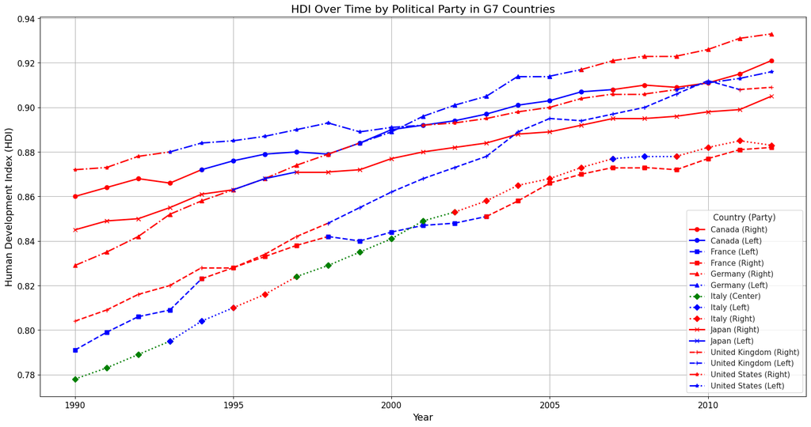

```python
plt.figure(figsize=(20, 10))

# use different line styles for different political parties
line_styles = {"Left": "-", "Center": "--", "Right": "-."}

party_colors = {"Left": "blue", "Center": "green", "Right": "red"}

# Define line styles and markers for each G7 country
country_styles = {
    'Canada': {'linestyle': '-', 'marker': 'o'},
    'France': {'linestyle': '--', 'marker': 's'},  # Square marker
    'Germany': {'linestyle': '-.', 'marker': '^'},  # Triangle up
    'Italy': {'linestyle': ':', 'marker': 'D'},    # Diamond marker
    'Japan': {'linestyle': '-', 'marker': 'x'},    # X marker
    'United Kingdom': {'linestyle': '--', 'marker': '+'},  # Plus marker
    'United States': {'linestyle': '-.', 'marker': '*'}    # Star marker
}

# loop plotting each contry's data
for country in merged_df['country'].unique():
  if country in country_styles:
    country_data = merged_df[merged_df['country'] == country]
    years = country_data['year'].unique()

    for i in range(len(years)-1):
      year_data = country_data[country_data['year'] == years[i]]
      next_year_data = country_data[country_data['year'] == years[i+1]]

      if not year_data.empty and not next_year_data.empty:
        plt.plot([years[i], years[i+1]],
          [year_data['hdi'].values[0], next_year_data['hdi'].values[0]],
          color=party_colors.get(year_data['execrlc'].values[0], 'black'),
          label=f"{country} ({year_data['execrlc'].values[0]})",
          linewidth=2,
          linestyle=country_styles[country]['linestyle'],
          marker=country_styles[country]['marker'])

# discripitve graph info
plt.title('HDI Over Time by Political Party in G7 Countries', fontsize=16)
plt.xlabel('Year', fontsize=14)
plt.ylabel('Human Development Index (HDI)', fontsize=14)
plt.xticks(fontsize=12)
plt.yticks(fontsize=12)
plt.grid(True) #add gridlines
sns.set(style="whitegrid", rc={"lines.linewidth": 3}) # increase line thickness

# legend modification
handles, labels = plt.gca().get_legend_handles_labels()
by_label = dict(zip(labels, handles))
plt.legend(by_label.values(), by_label.keys(), loc='lower right', title='Country (Party)')

# change color of the line over time by the political party (using for loop)
```

All G7 countries have shown an increase in HDI over the 20-year period regardless of the political party in power. There doesn't seem to be a consistent pattern where one particular political orientation (left, center, right) leads to a significantly better or worse HDI. In some countries, like Canada and Italy, the left-leaning parties show the highest HDI growth, while in others, like the United Kingdom, the right-leaning parties demonstrate the highest growth. The HDI growth trajectories vary between countries. For instance, the HDI growth in the United States is relatively flat compared to other countries, regardless of the party in power. Conversely, countries like Italy and Germany show a steeper increase in HDI over time.

Looking at this graph, we hypothesize that left or right does not matter because, reguarless, the HDI scores have been consistently increasing, with none of the countries taking a significant decrease. What would be interesting is to create a third variable that measures how long a party is consistently in power, based on the executive branch, and measure if this is a determinate of change in HDI score. Furthermore, instead of solely looking at the raw score, we are going to look at percent change in HDI score to calculate annual growth. Let's do both now:

**Consistency Score**

To normalize this measure across countries with different lengths of observation periods, we calculated the total number of years each country was observed in our dataset. This was crucial to ensure that our stability score is not biased by the duration for which a country's data is available. The next step was to aggregate these yearly changes for each country and divide by the total years observed, giving us a preliminary score where a higher value indicated more frequent changes, and thus, lower stability.

Finally, we refined this measure into a more intuitive 'consistency score' by inverting it (subtracting preliminary score from 1). A higher score indicates higher political stability, aligning with the general understanding that less frequent changes in executive power signify a more consistent government overall. Additionally, we also handled any NaN or infinite values by replacing them with 1, ensuring our scores remained within a logical range. This final consistency score provides a standardized measure of political stability across countries.

```python
# Check unique values in 'country' column to ensure correct grouping
print("Unique countries:", merged_df['country'].unique())

# Ensure correct data types
merged_df['year'] = merged_df['year'].astype(int)
merged_df['execrlc'] = merged_df['execrlc'].astype(str)

# Calculate changes in party
merged_df['party_change'] = merged_df.groupby('country')['execrlc'].shift(1) != merged_df['execrlc']

# Fill NaN values in 'party_change' with 0
merged_df['party_change'] = merged_df['party_change'].fillna(0)

# Calculate total number of years observed for each country
merged_df['years_observed'] = merged_df.groupby('country')['year'].transform('count')

# Debug: Print a sample of the DataFrame to check calculations
print(merged_df[['country', 'year', 'execrlc', 'party_change', 'years_observed']].head(20))

# Check for zero years_observed
print("Countries with zero years_observed:", merged_df[merged_df['years_observed'] == 0]['country'].unique())

# Calculate the sum of party changes for each country
party_change_sum = merged_df.groupby('country')['party_change'].sum()

# Debug: Print the party_change_sum
print("Party change sum:\n", party_change_sum)

# Normalize by years observed
consistency_scores = party_change_sum / merged_df.groupby('country')['years_observed'].mean()

# Debug: Print the raw consistency scores
print("Raw consistency scores:\n", consistency_scores)

# Invert the score for ranking (less change = more stable)
consistency_scores = 1 - consistency_scores

# Handle NaN or infinite values
consistency_scores.fillna(1, inplace=True)
consistency_scores.replace([float('inf'), -float('inf')], 1, inplace=True)

# Rank countries by consistency score
ranked_countries = consistency_scores.sort_values(ascending=False)

# Debug: Check the final ranked scores
print("Ranked consistency scores:\n", ranked_countries)
```

```
Unique countries: ['Canada' 'France' 'Germany' 'Italy' 'Japan' 'United Kingdom'
 'United States']
   country  year execrlc  party_change  years_observed
0   Canada  1990   Right          True              23
1   Canada  1991   Right         False              23
2   Canada  1992   Right         False              23
3   Canada  1993   Right         False              23
4   Canada  1994    Left          True              23
5   Canada  1995    Left         False              23
6   Canada  1996    Left         False              23
7   Canada  1997    Left         False              23
8   Canada  1998    Left         False              23
9   Canada  1999    Left         False              23
10  Canada  2000    Left         False              23
11  Canada  2001    Left         False              23
12  Canada  2002    Left         False              23
13  Canada  2003    Left         False              23
14  Canada  2004    Left         False              23
15  Canada  2005    Left         False              23
16  Canada  2006    Left         False              23
17  Canada  2007   Right          True              23
18  Canada  2008   Right         False              23
19  Canada  2009   Right         False              23
Countries with zero years_observed: []
Party change sum:
 country
Canada            3
France            4
Germany           3
Italy             7
Japan             3
United Kingdom    3
United States     4
Name: party_change, dtype: int64
Raw consistency scores:
 country
Canada            0.130435
France            0.173913
Germany           0.130435
Italy             0.304348
Japan             0.130435
United Kingdom    0.130435
United States     0.173913
dtype: float64
Ranked consistency scores:
 country
Canada            0.869565
Germany           0.869565
Japan             0.869565
United Kingdom    0.869565
France            0.826087
United States     0.826087
Italy             0.695652
dtype: float64
```

**HDI Growth**

Now that consistency score is calculated, let's make a percent change variable that we will call 'hdi_growth'. This is fairly simple. Using the built in functions, we can easily calculate this.

```python
# Calculate the year-over-year HDI growth
merged_df['hdi_growth'] = merged_df.groupby('country')['hdi'].pct_change()

# Drop rows with NaN in 'hdi_growth'
merged_df.dropna(subset=['hdi_growth'], inplace=True)

print(merged_df["hdi_growth"])
```

```
1      0.004651
2      0.004630
3     -0.002304
4      0.006928
5      0.004587
         ...
156    0.000000
157    0.002208
158    0.003304
159    0.002195
160    0.003286
Name: hdi_growth, Length: 154, dtype: float64
```

## 5. Prediction Model

Now that all the set up is finished, let's create a preditive model that will reveal the relationship between HDI score and political party as well as our reformed hypothesis, HDI growth and political consistency. To do this, we are going to regress left and right political lean as well as the consistency score on the Human Development Index (HDI). Then, we will calculate our error rates.

```python
from sklearn.model_selection import train_test_split
from sklearn.linear_model import LinearRegression
from sklearn.metrics import mean_squared_error, r2_score
import numpy as np

# Convert political orientation into dummy variables
merged_df['left'] = (merged_df['execrlc'] == 'Left').astype(int)
merged_df['right'] = (merged_df['execrlc'] == 'Right').astype(int)

# Merge consistency scores into the main DataFrame
merged_df = merged_df.merge(consistency_scores.rename('consistency_scores'), on='country')

# Selecting the independent variables and the dependent variable
X = merged_df[['left', 'right', 'consistency_scores']]
y = merged_df['hdi']

# Splitting the dataset into training and testing sets
X_train, X_test, y_train, y_test = train_test_split(X, y, test_size=0.2, random_state=42)

# Initialize and train the linear regression model
model = LinearRegression()
model.fit(X_train, y_train)

# Get coefficients
coefficients = model.coef_

# Print the coefficients
print("Coefficients:")
print("Left:", coefficients[0])
print("Right:", coefficients[1])
print("Consistency Score:", coefficients[2])

# Predicting HDI
y_pred = model.predict(X_test)

# Evaluating the model
mse = mean_squared_error(y_test, y_pred)
r2 = r2_score(y_test, y_pred)

print("\nMean Squared Error:", mse)
print("R^2 Score:", r2)
```

```
Coefficients:
Left: 0.014484738623220484
Right: 0.011421588037068223
Consistency Score: 0.18920868733311447

Mean Squared Error: 0.0008372372789526706
R^2 Score: 0.2731238503348823
```

**Coefficient Interpretations**

Our multiple regression model has provided insightful results about the impact of political orientation and political stability on a country's Human Development Index (HDI). The coefficients below indicate the degree of influence each factor has on the HDI.

Left-Wing (Coefficient: 0.0145): This positive coefficient suggests that a shift towards left-wing orientation is associated with a slight increase in the HDI. Specifically, for each unit increase in the measure of left-wing orientation, we expect the HDI to increase by approximately 0.0145, assuming other factors remain constant. This could imply that policies typically associated with left-wing politics, such as social welfare or equality measures, might have a beneficial impact on human development.

Right-Wing (Coefficient: 0.0114): The positive coefficient here, though slightly smaller than that for left-wing, indicates that right-wing orientation also positively influences the HDI. A unit increase in right-wing orientation is associated with an increase of about 0.0114 in the HDI. This might reflect the potential benefits of policies used by right-wing parties, such as economic liberalization or conservative social reforms.

Consistency Score (Coefficient: 0.1892): The relatively large coefficient for the consistency score, which measures political stability, underscores its significant impact on HDI. An increase in political stability leads to a substantial increase in HDI, with a coefficient more than ten times larger than those for political orientation demonstrating the crucial role of stable governance in promoting human development.

Regarding the model's performance, the mean squared error (MSE) is 0.000837, indicating the average squared difference between the observed actual outcomes and the outcomes predicted by the model. A lower MSE suggests better model performance. The R^2 score of 0.2731, while not exceptionally high, indicates that about 27% of the variability in HDI can be explained by our model. This suggests that while political orientation and stability are important factors, other variables not included in the model also play a significant role in determining HDI.

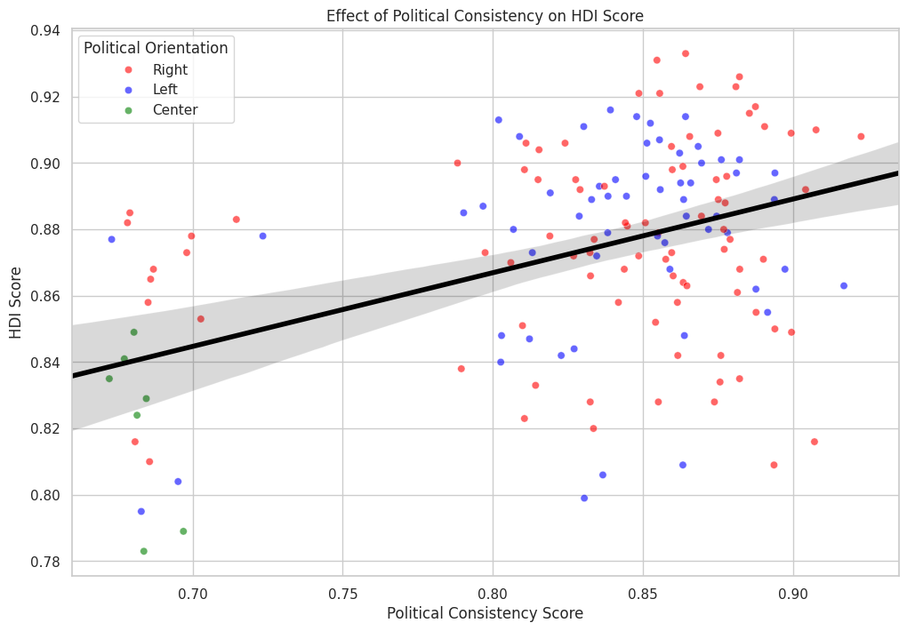

```python
# Create a scatter plot with a regression line
plt.figure(figsize=(12, 8))

# Jittering x-axis values for clarity
consistency_jittered = merged_df['consistency_scores'] + np.random.normal(0, 0.02, size=len(merged_df))

# Create a scatter plot
sns.scatterplot(x=consistency_jittered, y='hdi', data=merged_df, alpha=0.6, hue='execrlc', palette=['red', 'blue', 'green'])

# Add a regression line (without jitter)
sns.regplot(x='consistency_scores', y='hdi', data=merged_df, scatter=False, color='black', truncate=False, line_kws={'linewidth': 4})

plt.title('Effect of Political Consistency on HDI Score')
plt.xlabel('Political Consistency Score')
plt.ylabel('HDI Score')
plt.legend(title='Political Orientation')
plt.show()
```

Looking at the graph, there is a clear direct relationship between consistency score and the raw HDI score with a very diverse mix of poltical orientation or lean. Noticeably, the political party itself is not an indicator of HDI score.Additionally, there are very few center leaning points. This is due to center oriented political parties not being elected as oftern.

Let's run the same regression but use HDI growth as our y variable:

```python
# Selecting the independent variables and the dependent variable
X = merged_df[['left', 'right', 'consistency_scores']]
y = merged_df['hdi_growth']

# Splitting the dataset into training and testing sets
X_train, X_test, y_train, y_test = train_test_split(X, y, test_size=0.2, random_state=42)

# Initialize and train the linear regression model
model = LinearRegression()
model.fit(X_train, y_train)

# Get coefficients
coefficients = model.coef_

# Print the coefficients
print("Coefficients:")
print("Left:", coefficients[0])
print("Right:", coefficients[1])
print("Consistency Score:", coefficients[2])

# Predicting HDI
y_pred = model.predict(X_test)

# Evaluating the model
mse = mean_squared_error(y_test, y_pred)
r2 = r2_score(y_test, y_pred)

print("\nMean Squared Error:", mse)
print("R^2 Score:", r2)
```

```
Coefficients:
Left: -0.00296619483394267
Right: -0.0035134149670588465
Consistency Score: -0.002339420609040174

Mean Squared Error: 1.0226723596710013e-05
R^2 Score: -0.007974914669787836
```

**Coefficient Interpretations**

What jumps out immediately is that almost all values are negative, except for MSE. Though negative, consistency score still manages to be the least negative, comparatively to left and right.

Addressing it's predictive capability, this model is useless. Though it has very low MSE, it's R-squared value is negative, meaning it's predictive capabilites are mute.

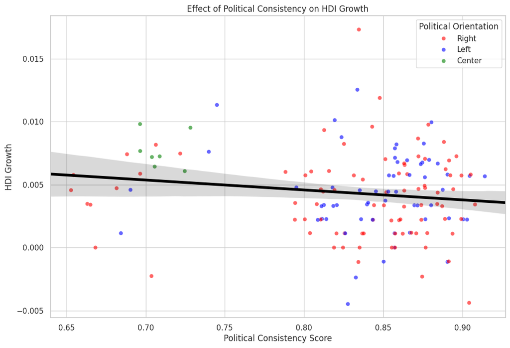

```python
# Create a scatter plot with a regression line
plt.figure(figsize=(12, 8))

# Jittering x-axis values for clarity
consistency_jittered = merged_df['consistency_scores'] + np.random.normal(0, 0.02, size=len(merged_df))

# Create a scatter plot
sns.scatterplot(x=consistency_jittered, y='hdi_growth', data=merged_df, alpha=0.6, hue='execrlc', palette=['red', 'blue', 'green'])

# Add a regression line (without jitter)
sns.regplot(x='consistency_scores', y='hdi_growth', data=merged_df, scatter=False, color='black', truncate=False, line_kws={'linewidth': 4})

plt.title('Effect of Political Consistency on HDI Growth')
plt.xlabel('Political Consistency Score')
plt.ylabel('HDI Growth')
plt.legend(title='Political Orientation')
plt.show()
```

Using HDI growth, there is a slight inverse relationship between. Compared to the raw HDI score model, the same remains true about the political orientation trends, the slope is much flatter. These trends are mute becuase the predictive capabilities are not functional.

## 6. Conclusion

Who is better for development? It doesn't matter who; it matters the duration. This finding is only applicable to the G7 countries in the late 20th century to early 20th century with well established democracies.

Conversion to HTML:

```python
!jupyter nbconvert --to html 'Politics on Development.ipynb' #convert to HTML
```

[output not shown]